# DataMining_hw1_XianjieQue

### 8-(c)-iv

```r
Elite <- rep("No", nrow(college))
Elite[college$Top10perc > 50] <- "Yes"
Elite <- as.factor(Elite)
college <- data.frame(college, Elite)

summary(Elite)  # There are 78 elite universities
```

```
##  No Yes
## 699  78
```

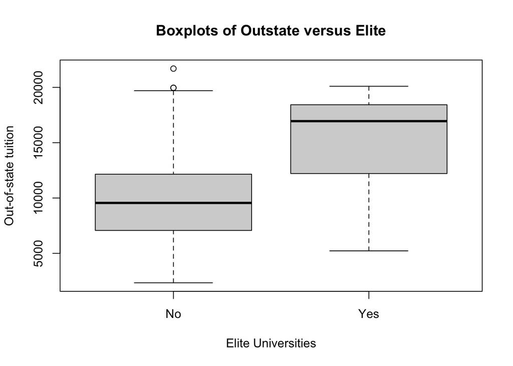

```r
plot(college$Elite, college$Outstate,
     xlab = 'Elite Universities',
     ylab = 'Out-of-state tuition',
     main = 'Boxplots of Outstate versus Elite'
     )
```

### 8-(c)-v

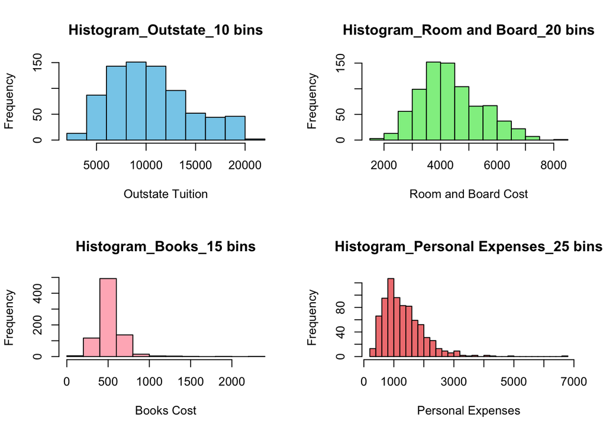

```r
par(mfrow = c(2, 2))

hist(college$Outstate,
     main = "Histogram_Outstate_10 bins",
     xlab = "Outstate Tuition",
     col = "skyblue",
     breaks = 10)

hist(college$Room.Board,
     main = "Histogram_Room and Board_20 bins",
     xlab = "Room and Board Cost",
     col = "lightgreen",
     breaks = 20)

hist(college$Books,
     main = "Histogram_Books_15 bins",
     xlab = "Books Cost",
     col = "lightpink",
     breaks = 15)

hist(college$Personal,
     main = "Histogram_Personal Expenses_25 bins",
     xlab = "Personal Expenses",
     col = "lightcoral",
     breaks = 25)
```

```r
par(mfrow = c(1, 1))
```

### 8-(c)-vi

A brief summary:

From the correlation between variables, we know that “Number of full-time undergraduates” has a strong positive correlation with Enrolled number, Accepted number and Applications number, but has almost nothing to do with “Instructional expenditure per student”.

At the same time, chi-square analysis is performed on the remaining two qualitative variables. Since the P-value is less than 0.05, whether a college is Private and Elite is not random.

[figure not shown]

```r
pairs(college)
```

```r
cor(college[, sapply(college, is.numeric)])
```

```
##                    Apps      Accept      Enroll  Top10perc   Top25perc
## Apps         1.00000000  0.94345057  0.84682205  0.3388337  0.35163990
## Accept       0.94345057  1.00000000  0.91163666  0.1924469  0.24747574
## Enroll       0.84682205  0.91163666  1.00000000  0.1812935  0.22674511
## Top10perc    0.33883368  0.19244693  0.18129353  1.0000000  0.89199497
## Top25perc    0.35163990  0.24747574  0.22674511  0.8919950  1.00000000
## F.Undergrad  0.81449058  0.87422328  0.96463965  0.1412887  0.19944466
## P.Undergrad  0.39826427  0.44127073  0.51306860 -0.1053563 -0.05357664
## Outstate     0.05015903 -0.02575455 -0.15547734  0.5623305  0.48939383
## Room.Board   0.16493896  0.09089863 -0.04023168  0.3714804  0.33148989
## Books        0.13255860  0.11352535  0.11271089  0.1188584  0.11552713
## Personal     0.17873085  0.20098867  0.28092946 -0.0933164 -0.08081027
## PhD          0.39069733  0.35575788  0.33146914  0.5318280  0.54586221
## Terminal     0.36949147  0.33758337  0.30827407  0.4911350  0.52474884
## S.F.Ratio    0.09563303  0.17622901  0.23727131 -0.3848745 -0.29462884
## perc.alumni -0.09022589 -0.15998987 -0.18079413  0.4554853  0.41786429
## Expend       0.25959198  0.12471701  0.06416923  0.6609134  0.52744743
## Grad.Rate    0.14675460  0.06731255 -0.02234104  0.4949892  0.47728116
##             F.Undergrad P.Undergrad    Outstate  Room.Board        Books
## Apps         0.81449058  0.39826427  0.05015903  0.16493896  0.132558598
## Accept       0.87422328  0.44127073 -0.02575455  0.09089863  0.113525352
## Enroll       0.96463965  0.51306860 -0.15547734 -0.04023168  0.112710891
## Top10perc    0.14128873 -0.10535628  0.56233054  0.37148038  0.118858431
## Top25perc    0.19944466 -0.05357664  0.48939383  0.33148989  0.115527130
## F.Undergrad  1.00000000  0.57051219 -0.21574200 -0.06889039  0.115549761
## P.Undergrad  0.57051219  1.00000000 -0.25351232 -0.06132551  0.081199521
## Outstate    -0.21574200 -0.25351232  1.00000000  0.65425640  0.038854868
## Room.Board  -0.06889039 -0.06132551  0.65425640  1.00000000  0.127962970
## Books        0.11554976  0.08119952  0.03885487  0.12796297  1.000000000
## Personal     0.31719954  0.31988162 -0.29908690 -0.19942818  0.179294764
## PhD          0.31833697  0.14911422  0.38298241  0.32920228  0.026905731
## Terminal     0.30001894  0.14190357  0.40798320  0.37453955  0.099954700
## S.F.Ratio    0.27970335  0.23253051 -0.55482128 -0.36262774 -0.031929274
## perc.alumni -0.22946222 -0.28079236  0.56626242  0.27236345 -0.040207736
## Expend       0.01865162 -0.08356842  0.67277862  0.50173942  0.112409075
## Grad.Rate   -0.07877313 -0.25700099  0.57128993  0.42494154  0.001060894
##                Personal         PhD    Terminal   S.F.Ratio perc.alumni
## Apps         0.17873085  0.39069733  0.36949147  0.09563303 -0.09022589
## Accept       0.20098867  0.35575788  0.33758337  0.17622901 -0.15998987
## Enroll       0.28092946  0.33146914  0.30827407  0.23727131 -0.18079413
```

[output cut: 17 more lines]

```
## Enroll       0.06416923 -0.022341039
## Top10perc    0.66091341  0.494989235
## Top25perc    0.52744743  0.477281164
## F.Undergrad  0.01865162 -0.078773129
## P.Undergrad -0.08356842 -0.257000991
## Outstate     0.67277862  0.571289928
## Room.Board   0.50173942  0.424941541
## Books        0.11240908  0.001060894
## Personal    -0.09789189 -0.269343964
## PhD          0.43276168  0.305037850
## Terminal     0.43879922  0.289527232
## S.F.Ratio   -0.58383204 -0.306710405
## perc.alumni  0.41771172  0.490897562
## Expend       1.00000000  0.390342696
## Grad.Rate    0.39034270  1.000000000
```

```r
chisq.test(college$Private, college$Elite)
```

```
##
##  Pearson's Chi-squared test with Yates' continuity correction
##
## data:  college$Private and college$Elite
## X-squared = 4.3498, df = 1, p-value = 0.03701
```

### 9-(a)

Answer: From the result of “summary(Auto)”, there are 9 predictors. “Name” is qualitative and the other 8 are quantitative. They are: “mpg”, “cylinders”, “displacement”, “horsepower”, “weight”, “acceleration”, “year”, “origin”.

```r
# load the Auto data set and remove missing values
Auto <- read.table("/Users/quexianjie/Desktop/1/SP2025.660 Biomedical Data Mining/hw1/Auto.data",
                   header = T, na.strings = "?", stringsAsFactors = T)
dim(Auto)
```

```
## [1] 397   9
```

```r
Auto <- na.omit(Auto)
dim(Auto)
```

```
## [1] 392   9
```

```r
summary(Auto)
```

```
##       mpg          cylinders      displacement     horsepower        weight
##  Min.   : 9.00   Min.   :3.000   Min.   : 68.0   Min.   : 46.0   Min.   :1613
##  1st Qu.:17.00   1st Qu.:4.000   1st Qu.:105.0   1st Qu.: 75.0   1st Qu.:2225
##  Median :22.75   Median :4.000   Median :151.0   Median : 93.5   Median :2804
##  Mean   :23.45   Mean   :5.472   Mean   :194.4   Mean   :104.5   Mean   :2978
##  3rd Qu.:29.00   3rd Qu.:8.000   3rd Qu.:275.8   3rd Qu.:126.0   3rd Qu.:3615
##  Max.   :46.60   Max.   :8.000   Max.   :455.0   Max.   :230.0   Max.   :5140
##
##   acceleration        year           origin                      name
##  Min.   : 8.00   Min.   :70.00   Min.   :1.000   amc matador       :  5
##  1st Qu.:13.78   1st Qu.:73.00   1st Qu.:1.000   ford pinto        :  5
##  Median :15.50   Median :76.00   Median :1.000   toyota corolla    :  5
##  Mean   :15.54   Mean   :75.98   Mean   :1.577   amc gremlin       :  4
##  3rd Qu.:17.02   3rd Qu.:79.00   3rd Qu.:2.000   amc hornet        :  4
##  Max.   :24.80   Max.   :82.00   Max.   :3.000   chevrolet chevette:  4
##                                                  (Other)           :365
```

### 9-(b)

```r
# create a vector "quanti_x" including all 8 quantitative predictors
x <- colnames(Auto)
quanti_x <- setdiff(x, "name")

# use a for loop to calculate the range for each predictor
ranges <- list()
for (i in quanti_x){
  ranges[[i]] <- range(Auto[[i]])
}
print(ranges)
```

```
## $mpg
## [1]  9.0 46.6
##
## $cylinders
## [1] 3 8
##
## $displacement
## [1]  68 455
##
## $horsepower
## [1]  46 230
##
## $weight
## [1] 1613 5140
##
## $acceleration
## [1]  8.0 24.8
##
## $year
## [1] 70 82
##
## $origin
## [1] 1 3
```

### 9-(c)

```r
# use a for loop to calculate the mean for each predictor
means <- list()
for (i in quanti_x){
  means[[i]] <- mean(Auto[[i]])
}
print(means)
```

```
## $mpg
## [1] 23.44592
##
## $cylinders
## [1] 5.471939
##
## $displacement
## [1] 194.412
##
## $horsepower
## [1] 104.4694
##
## $weight
## [1] 2977.584
##
## $acceleration
## [1] 15.54133
##
## $year
## [1] 75.97959
##
## $origin
## [1] 1.576531
```

```r
# use a for loop to calculate the standard deviation for each predictor
sds <- list()
for (i in quanti_x){
  sds[[i]] <- sd(Auto[[i]])
}
print(sds)
```

```
## $mpg
## [1] 7.805007
##
## $cylinders
## [1] 1.705783
##
## $displacement
## [1] 104.644
##
## $horsepower
## [1] 38.49116
##
## $weight
## [1] 849.4026
##
## $acceleration
## [1] 2.758864
##
## $year
## [1] 3.683737
##
## $origin
## [1] 0.8055182
```

### 9-(d)

```r
# remove the 10th through 85th observations
Auto_2 <- Auto[-c(10:85),]
dim(Auto_2)
```

```
## [1] 316   9
```

```r
# use the for loop to calculate the range again
ranges_2 <- list()
for (i in quanti_x){
  ranges_2[[i]] <- range(Auto_2[[i]])
}
print(ranges_2)
```

```
## $mpg
## [1] 11.0 46.6
##
## $cylinders
## [1] 3 8
##
## $displacement
## [1]  68 455
##
## $horsepower
## [1]  46 230
##
## $weight
## [1] 1649 4997
##
## $acceleration
## [1]  8.5 24.8
##
## $year
## [1] 70 82
##
## $origin
## [1] 1 3
```

```r
# use the for loop to calculate the mean again
means_2 <- list()
for (i in quanti_x){
  means_2[[i]] <- mean(Auto_2[[i]])
}
print(means_2)
```

```
## $mpg
## [1] 24.40443
##
## $cylinders
## [1] 5.373418
##
## $displacement
## [1] 187.2405
##
## $horsepower
## [1] 100.7215
##
## $weight
## [1] 2935.972
##
## $acceleration
## [1] 15.7269
##
## $year
## [1] 77.14557
##
## $origin
## [1] 1.601266
```

```r
# use the for loop to calculate the standard deviation again
sds_2 <- list()
for (i in quanti_x){
  sds_2[[i]] <- sd(Auto_2[[i]])
}
print(sds_2)
```

```
## $mpg
## [1] 7.867283
##
## $cylinders
## [1] 1.654179
##
## $displacement
## [1] 99.67837
##
## $horsepower
## [1] 35.70885
##
## $weight
## [1] 811.3002
##
## $acceleration
## [1] 2.693721
##
## $year
## [1] 3.106217
##
## $origin
## [1] 0.81991
```